# Figures for Paper

Dylan Glave

1/28/2022

## R Markdown

##### Reading in Data

```r
scaled_sum <- read.csv("scaled_sum.csv")
hhs_all_complete <- read_csv("hhs_all_complete.csv")
```

```
## * `` -> ...1
```

```r
scaled_km_df <- read_csv("scaled_km_df.csv")
```

```
## * `` -> ...1
```

We want to include a point where all responses are “neutral” on our map of compliance behaviors

```r
neutral_point <- scaled_sum %>%
filter(country == "NEUTRAL")
```

#### 1. Mapping Indices

We now have one (x,y) point for each fisher observation, and can map them onto an X-Y plane of Agreement and Engagement.

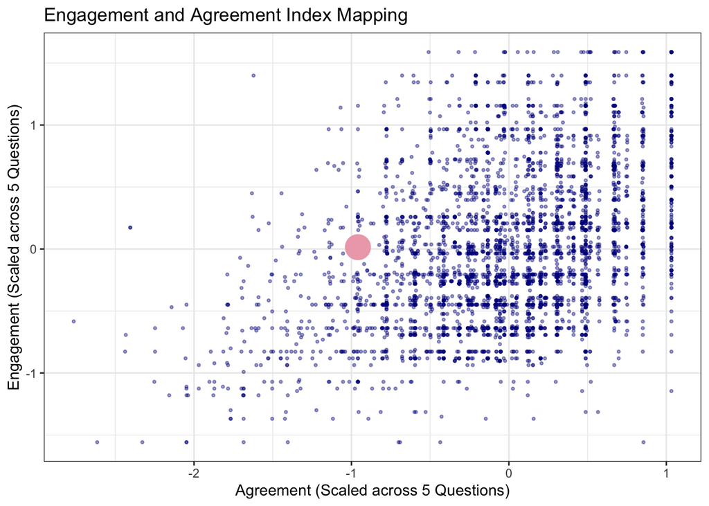

```r
  ggplot(data = scaled_sum,
                      aes(x = agree_mean, y = eng_mean)) +
   geom_point(color = "darkblue", size = 0.7, alpha = 0.4) +
  geom_point(data = neutral_point, aes(x = agree_mean, y = eng_mean),
             size = 8, color = "pink2") +
  labs( x = "Agreement (Scaled across 5 Questions)",
      y = "Engagement (Scaled across 5 Questions)",
      title = "Engagement and Agreement Index Mapping") +
#  scale_color_viridis(discrete = TRUE, option = "D") +
    # scale_x_continuous(limits = c(-3, 1.7),
    #                   breaks = c(-2, -1, 0, 1, 1.5)) +
   # scale_y_continuous(limits = c(-1.5, 1.5),
   #                   breaks = c( -1, 0, 1, 1.5)) +
  guides(colour = guide_legend(override.aes = list(size=7))) +
  theme_bw()
```

*Figure 1: A plot with the **neutral* fisher reported within the spread of our Z-score-based indices. We see that Ms. Neutral is 1 SD below the mean in agreement. This location means that the majority of fishers at least somewhat agree with rules in place. Meanwhile, we see dense grouping between -0.5 and 0.5 on both axes. Quite a few fishers have the maximum score for agreement, while a smaller number meet the *ceiling* of engagement.

Rare seems quite interested in addressing how fishers may be willing to *engage* more.

#### 2. Compliance Behaviors of Admitted rule-breakers

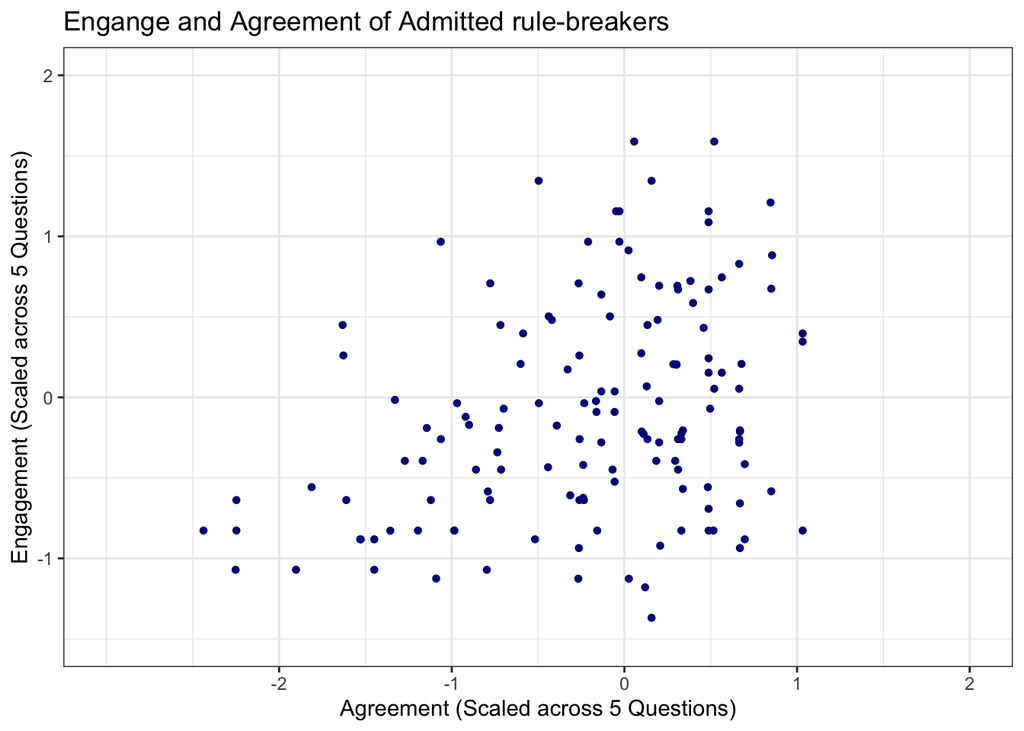

```r
counts_63 <- scaled_sum %>%
  count(x63_fishing_in_reserve, country)

filtered_63 <- scaled_sum %>%
  filter(x63_fishing_in_reserve == "1")

ggplot(data = filtered_63,
                      aes(x = agree_mean, y = eng_mean)) +
  geom_point(color = "darkblue", size = 1.2, alpha = 1,
             show.legend = TRUE) +
labs( x = "Agreement (Scaled across 5 Questions)",
      y = "Engagement (Scaled across 5 Questions)",
      title = "Engange and Agreement of Admitted rule-breakers") +
  scale_x_continuous(limits = c(-3, 2),
                     breaks = c(-2, -1, 0, 1, 2)) +
   scale_y_continuous(limits = c(-1.5, 2),
                     breaks = c( -1, 0, 1, 2)) +
  theme_bw()
```

Question 63 asks if fishers break the rules, and fish in the reserve. This would be a classic measure of compliance (although self-reporting likely leads to a lower N of admitted non-compliers)

*138* fishers admitted that they fish in the reserve, while 2800 said they do not. The question we’re left with is: What is different about folks who *admit* to breaking rules? These “Yes” rule-breakers are spread relatively evenly across all countries. Maybe they don’t think there are sanctions, their community doesn’t care about it

#### 3. Full Cluster Map

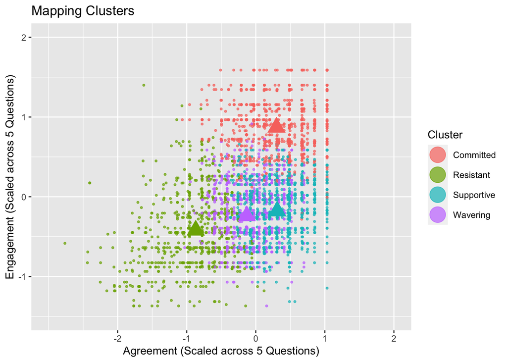

```r
cluster_summary_df <- scaled_km_df %>%
  group_by(cluster_no) %>%
  summarise(eng_mean = mean(eng_mean),
            agree_mean  = mean(agree_mean),
            x44_mean = mean(x44_meeting_attendance),
            x45_mean = mean(x45_leadership_position),
            x48_mean = mean(x48_enforcement_participation),
            x53_mean = mean(x53_encourage_regulations),
            x61g_mean = mean(x61g_fishing_change_behavior),
            x43_mean =  mean(x43_ma_benefits),
            x46_mean = mean(x46_represent_interests),
           x52_mean = mean(x52_ma_benefit_5yrs),
           x61a_mean = mean(x61a_current_regulations),
           x61f_mean = mean(x61f_rights_distribution_fair),
           x30a_mean = mean(x30_trust_local_decision),
           x44_median = median(x44_meeting_attendance),
            x45_median = median(x45_leadership_position),
            x48_median = median(x48_enforcement_participation),
            x53_median = median(x53_encourage_regulations),
            x61g_median = median(x61g_fishing_change_behavior),
            x43_median =  median(x43_ma_benefits),
            x46_median = median(x46_represent_interests),
           x52_median = median(x52_ma_benefit_5yrs),
           x61a_median = median(x61a_current_regulations),
           x61f_median = median(x61f_rights_distribution_fair),
            x30a_median = median(x30_trust_local_decision)) %>%
  mutate(across(where(is.numeric), ~ round(., 2)))
## Here, the last line of code rounds to the second decimal

cluster_medians <- cluster_summary_df %>%
  select(1, 14:23)

cl_mean_graphable_df <- cluster_summary_df %>%
  select(eng_mean, agree_mean, cluster_no)



scaled_cluster_counts <- scaled_km_df %>%
  count(cluster_no)


ggplot() +
  geom_point(data = scaled_km_df,
       aes(x = agree_mean, y = eng_mean,
           color = cluster_no),
           size = 0.7, alpha = 0.7) +
   geom_point(data = cl_mean_graphable_df,
             aes(x = agree_mean, y = eng_mean,
          color = cluster_no),
           size = 6, shape = "triangle", show.legend = FALSE) +
  labs( x = "Agreement (Scaled across 5 Questions)",
      y = "Engagement (Scaled across 5 Questions)",
      title = "Mapping Clusters",
      color = "Cluster") +
  scale_x_continuous(limits = c(-3, 2),
                     breaks = c(-2, -1, 0, 1, 2)) +
   scale_y_continuous(limits = c(-1.5, 2),
                     breaks = c( -1, 0, 1, 2)) +
   guides(colour = guide_legend(override.aes = list(size=7)))
```

The 4 Clusters, done marked by color. Means are marked by triangles.

Between Cluster 1 and 4 (our “average” fishers,) we see that C4 is a full sd higher on question 43 “Do you think there is any benefit to regulating fishing via a managed access area and a reserve area?”

Both C1 and C4 (average fishers) have higher values in question x61g (willingness to change fishing behavior for the sake of conservation,) and they slightly disagree with “encouraging others to follow regulations.”

*Average* fishers aren’t engaging much (including meeting attendance.) From an NGO perspective, if one wants to shift fisher behavior+attitudes, then try and bring the reluctant folks into the governance process.

#### 4. Perceived Catch + Clusters

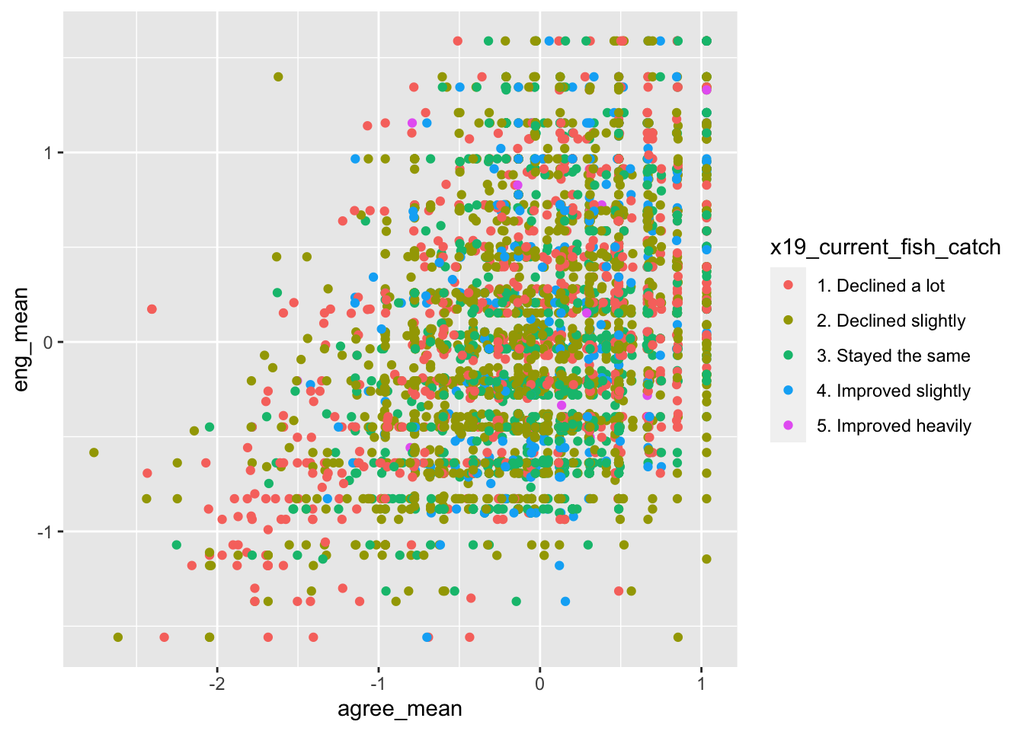

```r
no_na_19 <- scaled_km_df %>%
    drop_na(x19_current_fish_catch) %>%
 mutate(x19_current_fish_catch = recode_factor(x19_current_fish_catch,
    "Declined a lot" = "1. Declined a lot",
          "Declined slightly" = "2. Declined slightly",
           "Stayed the same" = "3. Stayed the same",
          "Improved slightly" = "4. Improved slightly",
          "Improved heavily" = "5. Improved heavily"))





mean_19_df <- no_na_19 %>%
        group_by(x19_current_fish_catch) %>%
        summarise(eng_mean = mean(eng_mean),
                  agree_mean  = mean(agree_mean))


ggplot(no_na_19,
       aes(x = agree_mean, y = eng_mean, color = x19_current_fish_catch)) +
  geom_point()
```

**Another Version of Perceived Catch**

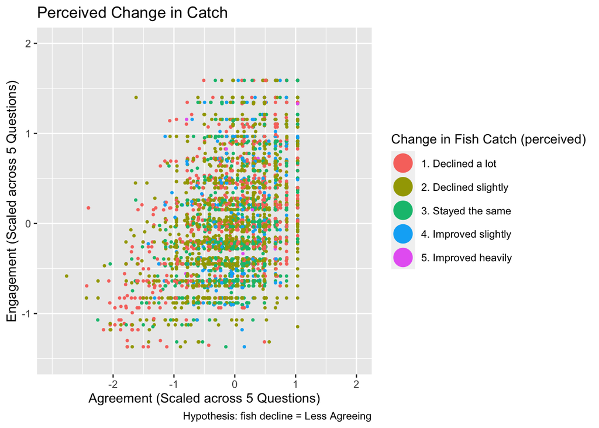

```r
ggplot(no_na_19,
       aes(x = agree_mean, y = eng_mean, color = x19_current_fish_catch)) +
  geom_point(size = 0.7) +
  labs( x = "Agreement (Scaled across 5 Questions)",
      y = "Engagement (Scaled across 5 Questions)",
      title = "Perceived Change in Catch",
      color = "Change in Fish Catch (perceived)",
      caption = "Hypothesis: fish decline = Less Agreeing") +
  scale_x_continuous(limits = c(-3, 2),
                     breaks = c(-2, -1, 0, 1, 2)) +
   scale_y_continuous(limits = c(-1.5, 2),
                     breaks = c( -1, 0, 1, 2)) +
  guides(colour = guide_legend(override.aes = list(size=7)))
```

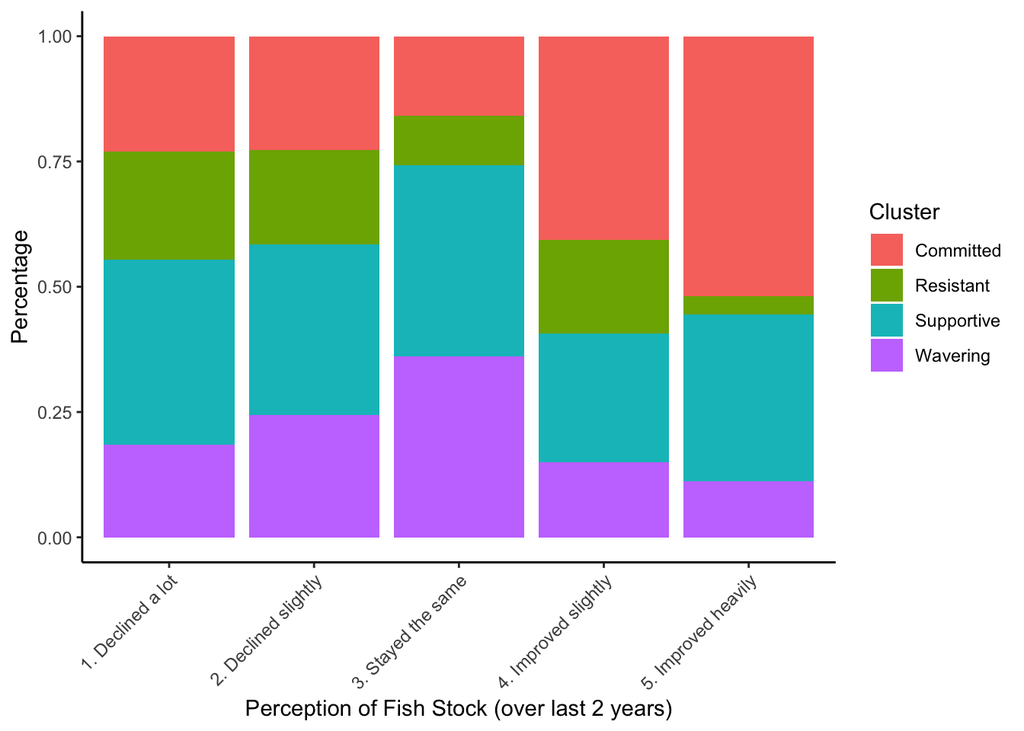

```r
x19_counts <- no_na_19 %>%
  count(x19_current_fish_catch)

x19_cluster_counts <- no_na_19 %>%
  group_by(cluster_no) %>%
  count(x19_current_fish_catch)


ggplot(x19_cluster_counts,
       aes(x = x19_current_fish_catch, y = n, fill = cluster_no,
           )) +
  geom_bar(position="fill", stat="identity") +
  labs( x = "Perception of Fish Stock (over last 2 years)",
      y = "Percentage",
      fill = "Cluster") +
    guides(colour = guide_legend(override.aes = list(size=7))) +
  theme_classic() +
  theme(axis.text.x = element_text(angle = 45, hjust=1))
```

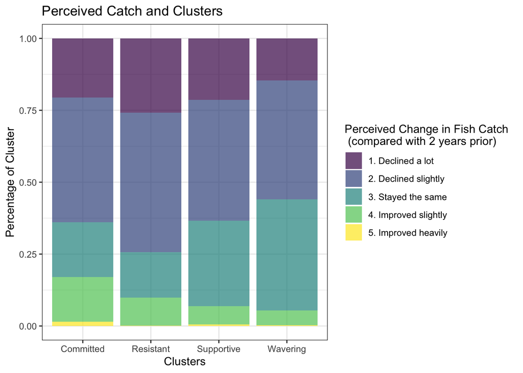

```r
reversed_x19_counts <-
  no_na_19 %>%
  group_by(x19_current_fish_catch) %>%
  count(cluster_no)

ggplot(reversed_x19_counts,
       aes(x = cluster_no, y = n, fill = x19_current_fish_catch)) +
  geom_bar(position="fill", stat="identity", alpha = 0.7) +
  labs( x = "Clusters",
      y = "Percentage of Cluster",
      title = "Perceived Catch and Clusters",
      fill = "Perceived Change in Fish Catch \n (compared with 2 years prior)") +
  scale_fill_viridis(discrete = T) +
  theme_bw()
```

Here’s a breakdown of the ecology question:

I just want to check the counts of x19 by country

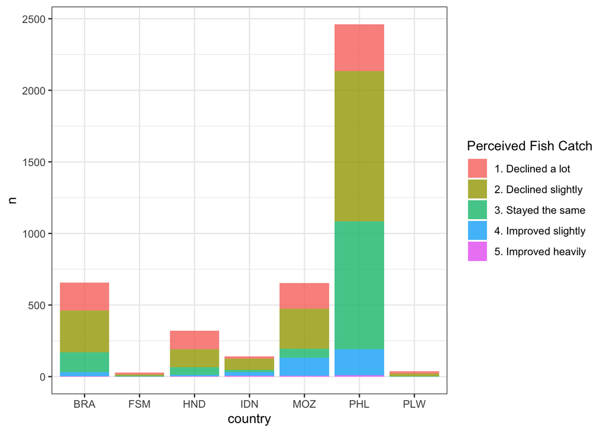

```r
x19_by_country <- no_na_19 %>%
  group_by(country) %>%
  count(x19_current_fish_catch)

ggplot(x19_by_country) +
  geom_bar( aes(x = country, y=n, fill = x19_current_fish_catch), stat="identity", alpha=0.8) +
  theme_bw() +
  labs(fill = "Perceived Fish Catch")
```

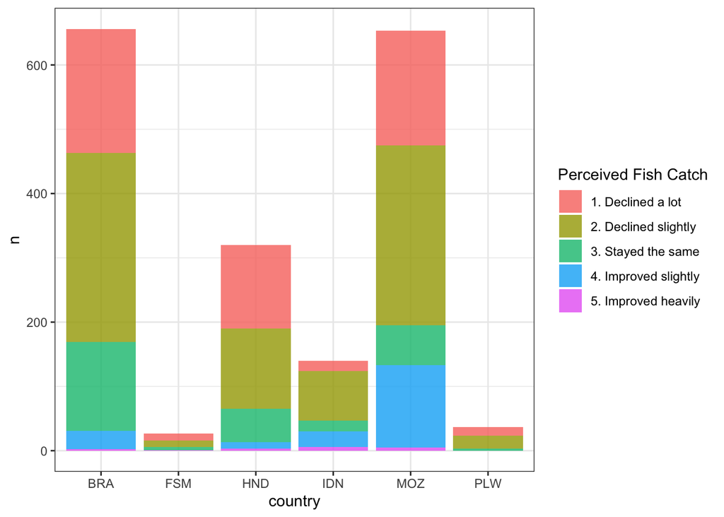

```r
x19_sans_phl <- no_na_19 %>%
  filter(country != "PHL") %>%
    group_by(country) %>%
  count(x19_current_fish_catch)

ggplot(x19_sans_phl) +
  geom_bar( aes(x = country, y=n, fill = x19_current_fish_catch), stat="identity", alpha=0.8) +
  theme_bw() +
  labs(fill = "Perceived Fish Catch")
```

##### 5. Fishing Effort in “Low Season”

```r
fishing_effort_17 <- scaled_km_df %>%
  filter(x17_fishing_low_profit %in% c("Once or never",
                                         "A few times",
                                         "A few times per month",
                                        "1-2 per week",
                                         "More than 1-2 times per week",
                                       na.rm = FALSE)) %>%
  drop_na(x17_fishing_low_profit) %>%
mutate(x17_fishing_low_profit = recode_factor(x17_fishing_low_profit, "Once or never" = "Rarely")) %>%
  mutate(x17_fishing_low_profit = recode_factor(x17_fishing_low_profit, "A few times" = "Rarely"))


x17_counts <- fishing_effort_17 %>%
  group_by(x17_fishing_low_profit) %>%
  count()

x17_cluster_counts <- fishing_effort_17 %>%
  group_by(cluster_no) %>%
  count(x17_fishing_low_profit)
```

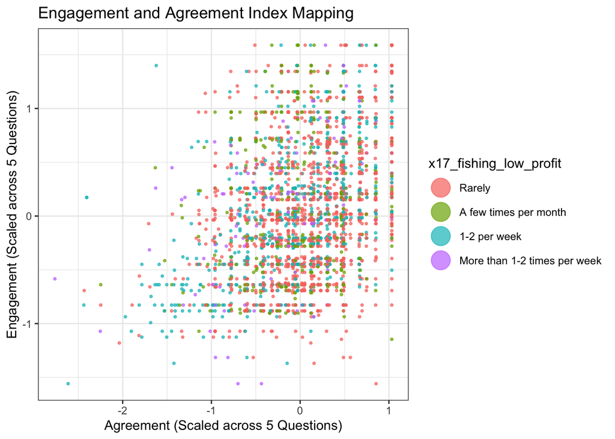

```r
ggplot(data = fishing_effort_17,  aes(x = agree_mean, y = eng_mean)) +
   geom_point(aes(color = x17_fishing_low_profit), size = 0.7, alpha = 0.7) +
  labs( x = "Agreement (Scaled across 5 Questions)",
      y = "Engagement (Scaled across 5 Questions)",
      title = "Engagement and Agreement Index Mapping") +
#  scale_color_viridis(discrete = TRUE, option = "D") +
    # scale_x_continuous(limits = c(-3, 1.7),
    #                   breaks = c(-2, -1, 0, 1, 1.5)) +
   # scale_y_continuous(limits = c(-1.5, 1.5),
   #                   breaks = c( -1, 0, 1, 1.5)) +
  guides(colour = guide_legend(override.aes = list(size=7))) +
  theme_bw()
```

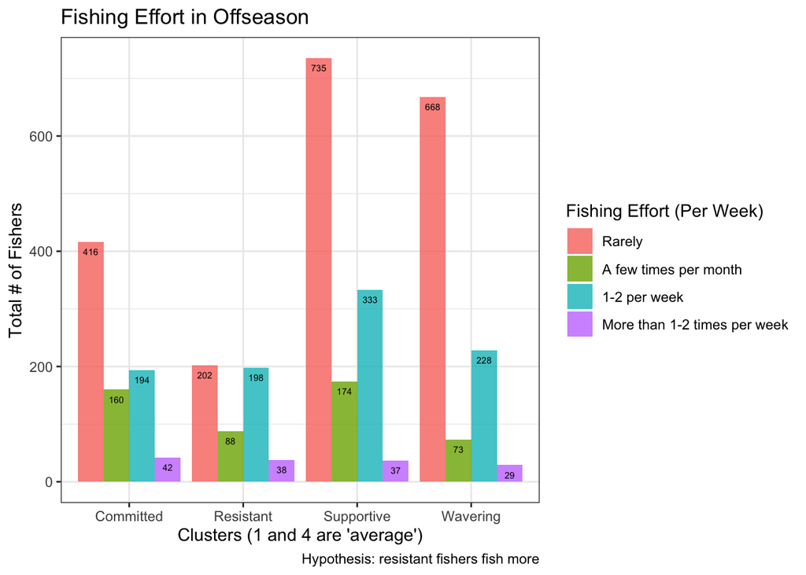

```r
ggplot(x17_cluster_counts,
       aes(x = cluster_no, y = n, fill = x17_fishing_low_profit)) +
  geom_bar(position="dodge", stat="identity", alpha = 0.8) +
  labs( x = "Clusters (1 and 4 are 'average')",
      y = "Total # of Fishers",
      title = "Fishing Effort in Offseason",
      fill = "Fishing Effort (Per Week)",
      caption = "Hypothesis: resistant fishers fish more") +
  geom_text(aes(label = n),position = position_dodge(0.9), vjust = 2, size = 2, color = "gray1")+
  theme_bw()
```

Second figure will be another stacked barplot This is rad! I’m going to code away at x18, and then do a little more interpreting.

##### 6. Fishing Effort in “High Season”

```r
x18_fishing_effort <- scaled_km_df %>%
  filter(x18_fishing_high_profit %in% c(
    "Once or never",
"A few times",
"A few times per month",
"1-2 per week",
"More than 1-2 times per week")) %>%
mutate(x18_fishing_high_profit = recode_factor(x18_fishing_high_profit, "Once or never" = "Rarely")) %>%
  mutate(x18_fishing_high_profit = recode_factor(x18_fishing_high_profit, "A few times" = "Rarely")) %>%
  drop_na(x18_fishing_high_profit)

# basic counts

x18_counts <- x18_fishing_effort %>%
  count(x18_fishing_high_profit)

x18_cluster_counts <- x18_fishing_effort %>%
  group_by(cluster_no) %>%
  count(x18_fishing_high_profit)
```

Let’s do the same visualization for 18, as I did for 17.

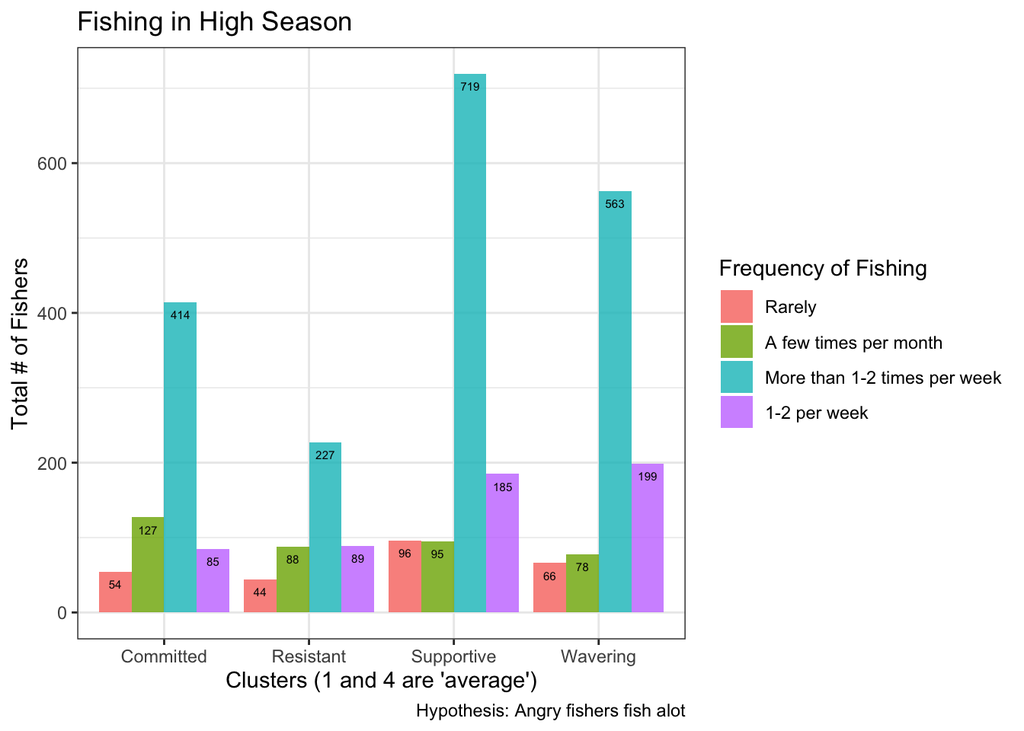

```r
ggplot(x18_cluster_counts,
       aes(x = cluster_no, y = n, fill = x18_fishing_high_profit)) +
  geom_bar(position="dodge", stat="identity", alpha = 0.8) +
  labs( x = "Clusters (1 and 4 are 'average')",
      y = "Total # of Fishers",
      title = "Fishing in High Season",
      fill = "Frequency of Fishing",
      caption = "Hypothesis: Angry fishers fish alot") +
  geom_text(aes(label = n),position = position_dodge(0.9), vjust = 2, size = 2, color = "gray1")+
  theme_bw()
```